# ascotraceR

## Introduction to *ascotraceR*

*ascotraceR* is an R package of the ‘ascotraceR’ model developed to simulate the spread of Ascochyta blight in a chickpea field over a growing season. Parameters and variables used in the model were mostly derived from the literature and were subjected to validation in the field. The model uses daily weather data to simulate disease spread and a set of weather data is included with the package for demonstration purposes.

### Getting started

Load the libraries.

```r
library("ascotraceR")
library("lubridate")
library("ggplot2")
library("data.table")
```

Import the weather data

```r
# weather data
Billa_Billa <- fread(
  system.file(
    "extdata",
    "2020_Billa_Billa_weather_data_ozforecast.csv",
    package = "ascotraceR"
  )
)

# format time column
Billa_Billa[, local_time := dmy_hm(local_time)]

# specify the station coordinates of the Billa Billa weather station
Billa_Billa[, c("lat", "lon") := .(-28.1011505, 150.3307084)]

head(Billa_Billa)
```

```
##    day          local_time assessment_number mean_daily_temp wind_ km_h   ws
## 1:   1 2020-06-04 00:00:00                NA             4.1        0.9 0.25
## 2:   1 2020-06-04 00:15:00                NA             3.9        0.6 0.17
## 3:   1 2020-06-04 00:30:00                NA             3.9        2.0 0.56
## 4:   1 2020-06-04 00:45:00                NA             4.3        1.2 0.33
## 5:   1 2020-06-04 01:00:00                NA             3.7        2.4 0.67
## 6:   1 2020-06-04 01:15:00                NA             3.5        1.3 0.36
##    ws_sd  wd wd_sd cummulative_rain_since_9am rain_mm wet_hours    location
## 1:    NA 215    NA                          0       0        NA Billa_Billa
## 2:    NA 215    NA                          0       0        NA Billa_Billa
## 3:    NA 215    NA                          0       0        NA Billa_Billa
## 4:    NA 215    NA                          0       0        NA Billa_Billa
## 5:    NA 215    NA                          0       0        NA Billa_Billa
## 6:    NA 215    NA                          0       0        NA Billa_Billa
##          lat      lon
## 1: -28.10115 150.3307
## 2: -28.10115 150.3307
## 3: -28.10115 150.3307
## 4: -28.10115 150.3307
## 5: -28.10115 150.3307
## 6: -28.10115 150.3307
```

### Wrangle weather data

A function, `format_weather()`, is provided to convert raw weather data into the format appropriate for the model. It is mandatory to format weather data before running the model. Time zone can also be set manually using `time_zone` argument. If latitude and longitude are not supplied in the raw weather data, a a separate CSV file listing latitude and longitude can be supplied to meet this requirement (see `?format_weather` for more details).

```r
Billa_Billa <- format_weather(
  x = Billa_Billa,
  POSIXct_time = "local_time",
  temp = "mean_daily_temp",
  ws = "ws",
  wd_sd = "wd_sd",
  rain = "rain_mm",
  wd = "wd",
  station = "location",
  time_zone = "Australia/Brisbane",
  lon = "lon",
  lat = "lat"
)
```

### Simulate Ascochyta blight spread

A function, `trace_asco()`, is provided to simulate the spread of Ascochyta blight in a chickpea field over a growing season. The inputs needed to run the function include weather data, paddock length and width, sowing and harvest dates, chickpea growing points replication rate, primary infection intensity, latent period, number of conidia produced per lesion and the location of primary infection foci (centre or random). The model output is a nested list with items for each day of the model run. See the help file for `trace_asco()` for more information.

```r
# Predict Ascochyta blight spread for the year 2020 at Billa Billa
traced <- trace_asco(
  weather = Billa_Billa,
  paddock_length = 20,
  paddock_width = 20,
  initial_infection = "2020-07-17",
  sowing_date = "2020-06-04",
  harvest_date = "2020-10-27",
  time_zone = "Australia/Brisbane",
  seeding_rate = 40,
  gp_rr = 0.0065,
  spores_per_gp_per_wet_hour = 0.6,
  latent_period_cdd = 150,
  primary_inoculum_intensity = 100,
  primary_infection_foci = "centre"
)
```

### Tidy up or summarise the model output

Functions `tidy_trace()` and `summarise_trace()` have been provided to tidy up and summarise the model output

## Tidy up the model output

```r
tidied <- tidy_trace(traced)
tidied
```

```
##        i_day     i_date day  x  y      new_gp susceptible_gp exposed_gp
##     1:     1 2020-06-04 156  1  1 40.00000000         40.000          0
##     2:     1 2020-06-04 156  1  2 40.00000000         40.000          0
##     3:     1 2020-06-04 156  1  3 40.00000000         40.000          0
##     4:     1 2020-06-04 156  1  4 40.00000000         40.000          0
##     5:     1 2020-06-04 156  1  5 40.00000000         40.000          0
##    ---
## 58796:   147 2020-10-28 302 20 16  0.03382666       4980.241          0
## 58797:   147 2020-10-28 302 20 17  0.03382666       4980.241          0
## 58798:   147 2020-10-28 302 20 18  0.03382666       4980.241          0
## 58799:   147 2020-10-28 302 20 19  0.03382666       4980.241          0
## 58800:   147 2020-10-28 302 20 20  0.03382666       4980.241          0
##        infectious_gp      cdd cwh cr gp_standard
##     1:             0    0.000   0  0      40.000
##     2:             0    0.000   0  0      40.000
##     3:             0    0.000   0  0      40.000
##     4:             0    0.000   0  0      40.000
##     5:             0    0.000   0  0      40.000
##    ---
## 58796:             0 2215.577  74 97    4980.241
## 58797:             0 2215.577  74 97    4980.241
## 58798:             0 2215.577  74 97    4980.241
## 58799:             0 2215.577  74 97    4980.241
## 58800:             0 2215.577  74 97    4980.241
```

### Summarise the model output

```r
summarised <- summarise_trace(traced)
summarised
```

```
##      i_day      new_gp susceptible_gp exposed_gp infectious_gp     i_date day
##   1:     1 16000.00000       16000.00          0             0 2020-06-04 156
##   2:     2  1108.59107       17108.59          0             0 2020-06-05 157
##   3:     3  1334.03497       18442.63          0             0 2020-06-06 158
##   4:     4  1492.26177       19934.89          0             0 2020-06-07 159
##   5:     5  1793.24969       21728.14          0             0 2020-06-08 160
##  ---
## 143:   143    30.57255     1992024.53          3           614 2020-10-24 298
## 144:   144    22.04597     1992046.58          3           614 2020-10-25 299
## 145:   145    19.99162     1992066.57          3           614 2020-10-26 300
## 146:   146    15.39628     1992078.97          0           617 2020-10-27 301
## 147:   147    14.05252     1992093.02          0           617 2020-10-28 302
##             cdd cwh   cr gp_standard   AUDPC
##   1:    0.00000   0  0.0    40.00000 42441.5
##   2:   10.74583   0  0.0    42.77148 42441.5
##   3:   22.84583   0  0.0    46.10657 42441.5
##   4:   35.41042   0  0.0    49.83722 42441.5
##   5:   49.38958   1  0.6    54.32034 42441.5
##  ---
## 143: 2133.81645  65 76.2  4980.06672 42441.5
## 144: 2154.64770  73 94.4  4980.12110 42441.5
## 145: 2176.49562  73 94.4  4980.17042 42441.5
## 146: 2195.63104  73 94.4  4980.20748 42441.5
## 147: 2215.57687  74 97.0  4980.24131 42441.5
```

## Plot using *ggplot2*

Plot the number of infectious growing points on day 132.

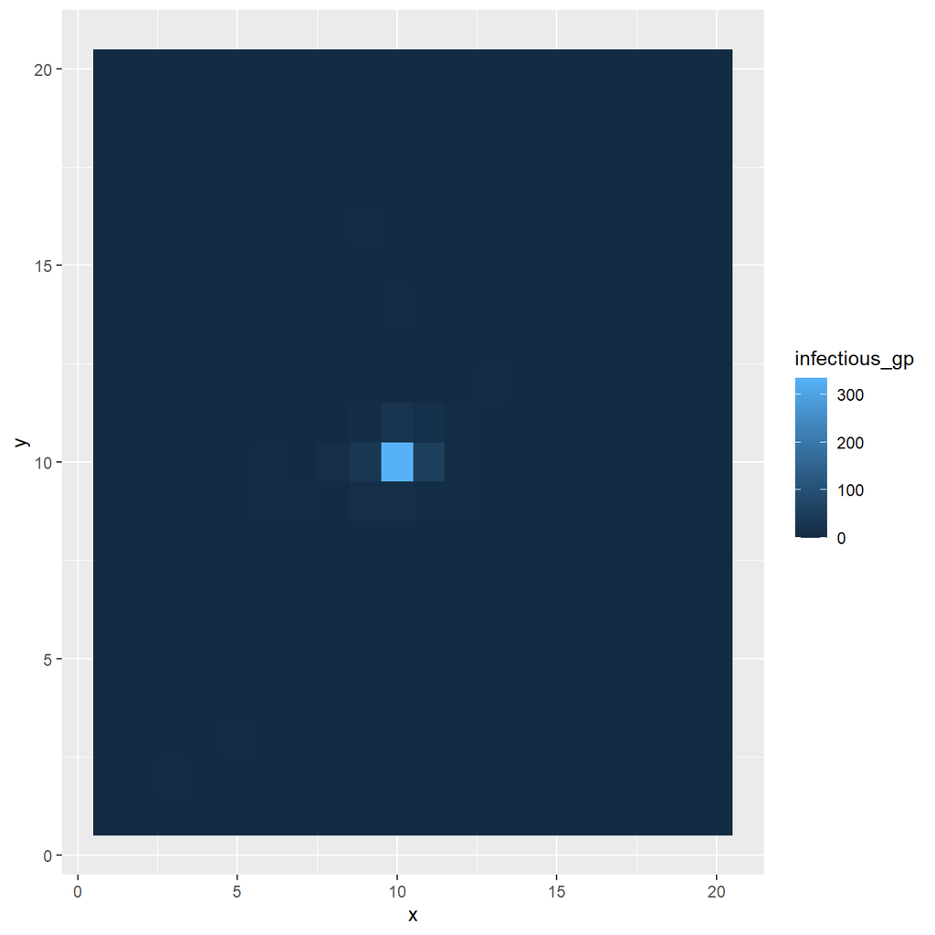

```r
ggplot(data = subset(tidied, i_day == 132),
       aes(x = x, y = y, fill = infectious_gp)) +
  geom_tile()
```